# Estadística Inferencia

# Distribuciones de muestreo fundamentales y descripciones de datos.

## Muestreo aleatorio

### Población y muestras

Definición: Una población consiste en la totalidad de las observaciones en las que estamos interesados

Definición: Una muestra es un subconjunto de una población

Definición: Sean $X_{1},X_{2},...,X_{n}$ n variables independientes, cada una con una misma distribución de probabilidad $f(x)$. Definimos $X_{1},...,X_{n}$ con una muestra aleatoria de tamaño $n$ de la población $f(x)$ y escribimos su distribución de probabilidad conjunta como
$$f(x_{1},...,x_{n})=f(x_{1})...f(x_{n})$$

## Algunos estadísticos importantes

Definición: Cualquier función de las variables aleatorias que forman una muestra aleatoria se llama estadístico

### Tendencia central en la muestra.

Definición: Si $X_{1},X_{2},...,X_{n}$ representan una muestra aleatoria de tamaño $n$, entonces **media de la muestra** se define mediante el estadístico
$$\bar{X}= \frac{1}{n}\sum_{i=1}^{n}X_{i}$$
Existen otros tipos de medias que se ajustan según la situación y la caracteristica de los datos u observaciones que se tienen. Una de estas variaciones es el *media truncada*, la cual calcula el promedio dejando por fuera un número fijo de valores aleatorios en cada extremo y luego encontrando la media con los valores de las observaciones restantes.

Definición: si $X_{1},X_{2},...,X_{n}$ representa una muestra aleatoria de tamaño $n$, entonces la **media truncada** se define mediante el estadístico con $p$ valores más pequeños y más grandes omitidos es:
$$\bar{X}=\frac{\sum_{i=p+1}^{n-p}X_{i}}{n-2p}$$
La media es sensible a valores extremos, por lo tanto la media truncada elimina la influencia de valores extremos.

Otro tipo de media es la **media ponderada**, que se calcula multiplicando cada observación o dato $X_{i}$ con un peso $w_{i}$ ya especificado y dividiendo esta suma por la suma de los pesos

Definición: Si $X_{1},X_{2},...,X_{n}$ representa una muestra aleatoria de tamaño $n$, entonces la **media ponderada** se define mediante el estadístico

$$\bar{X}_{w}= \frac{\sum_{i=1}^{n}w_{i}X_{i}}{\sum_{i=1}^{n}w_{i}}$$
Existen dos motivaciones por la cual utilizamos este tipo de promedio. 1. Algunos valores son intrinsecamente mas variables que otros, y estos valores con alta variabilidad se le da un peso menos. Por ejemplo si estamos tomando el promedio de multiples sensonres y uno de estos sensores tiene poca presición, entonces podemos bajar su influencia utilizando los pesos para este sensor.

2. Las observaciones o datos obtenimos no representan de manera equitativa diferentes grupos de los cuales queremos realizar mediciones. Por ejemplo debido a como un experimento en linea fue implementado fue realizado, no tenemos datos que reflejen de manera precisa todos los grupos que deseamos estudiar. Para corregir esto podemos dar pesos de mayor valor a los grupos con baja representación.

Veamos el siguiente conjunto de datos.

```r
library(readr)
state <- read_csv("data/state.csv")
head(state)
```

| State | Population | Murder.Rate | Abbreviation |
| --- | --- | --- | --- |
| Alabama | 4779736 | 5.7 | AL |
| Alaska | 710231 | 5.6 | AK |
| Arizona | 6392017 | 4.7 | AZ |
| Arkansas | 2915918 | 5.6 | AR |
| California | 37253956 | 4.4 | CA |
| Colorado | 5029196 | 2.8 | CO |

En la tabla observamos las primeras seis filas del conjunto de datos que contiene la población y tasas de homicidio.

Encontremos la media de la población de los estados.

```r
mean(state[['Population']])
```

```
## [1] 6162876
```

```r
mean(state[['Population']], trim=0.1)
```

```
## [1] 4783697
```

Este trim=0.1 elimina o deja de considerar el 10% de los datos en cada extremo

```r
weighted.mean(state[['Murder.Rate']], w=state[['Population']])
```

```
## [1] 4.445834
```

### Varianza de la muestra

La varianza debería indicar como se dispersan las observaciones a partir del promedio. Es posible tener dos conjuntos de observaciones con las mismas media o mediana, y que difieran de manera considerable en la variabilidad de sus mediciones alrededor del promedio.

Considere las siguientes mediciones, en litros, para dos muestras de jugo de naranaja envasado por las compañias A y B

```r
Muestra_A <-c(0.97, 1.00, 0.94, 1.03, 1.06)
Muestra_B <-c(1.06, 1.01, 0.88, 0.91, 1.14)

df<-data.frame(Muestra_A,Muestra_B)
df
```

| Muestra_A | Muestra_B |
| --- | --- |
| 0.97 | 1.06 |
| 1.00 | 1.01 |
| 0.94 | 0.88 |
| 1.03 | 0.91 |
| 1.06 | 1.14 |

Ahora, encontremos la media de cada una de las muestras.

```r
cat("Media de la Muestra A: ", mean(Muestra_A))
```

```
## Media de la Muestra A:  1
```

```r
cat("Media de la Muestra B: ", mean(Muestra_B))
```

```
## Media de la Muestra B:  1
```

Vemos que ambas muestras tienen la misma media, $1.00$ litros. ¿Cómo podemos saber cual de las dos compañias envasa de manera mas uniforme? Buscamos en cual de las dos muestras la variabilidad o la dispersión de las observaciones respecto al promedio es menor.

**Definición**: Si $X_{1},X_{2},…,X_{n} representan una muestra aleatoria de tamaño $n$, entonces la **varianza de la muestra** se define con el estadistico
$$S^{2} = \frac{1}{n-1}\sum_{i=1}^{n}\left(X_{i}-\bar{X}\right)^{2}$$
El valor calculado de $S^{2}$ para una muestra dada se denota con $s^2$.

```r
cat("Varianza de la Muestra A", (sd(Muestra_A))^2)
```

```
## Varianza de la Muestra A 0.00225
```

```r
cat("Varianza de la Muestra B",(sd(Muestra_B))^2)
```

```
## Varianza de la Muestra B 0.01145
```

Por lo tanto vemos que si compramos un jugo de naranja, tendríamos más confianza de que el envase seleccionado esté más cerca del promedio anunciado si lo compramos a la compañia A.

**Ejemplo:** Una comparación de los precios de café en cuatro tiendas de abarrotes, seleccionadas al azar, en San Diego mostró aumentos en comparación con el mes anterior de 12,15,17 y 20 centavos para una bolsa de 1 libra. Encuentre la varianza de esta muestra aleatoria de aunmento de precio.

```r
Aumento_cafe <-c(12,15,17,20)
```

```r
Aumento_cafe_df <-data.frame(Aumento_cafe)
Aumento_cafe_df
```

| Aumento_cafe |
| --- |
| 12 |
| 15 |
| 17 |
| 20 |

Podemos utilizar la función sd(), que corresponde a la desviación estandar, y por definición el cuadrado de esta será el valor de la varianza.

```r
(sd(Aumento_cafe))^2
```

```
## [1] 11.33333
```

Existe una expresión alternativa para la varianza y que es un teorema: **Teorema:** Si $S^{2}$ es la varianza de una muestra aleatoria de tamaño $n$, podemos escribir:
$$S^{2}=\frac{1}{n(n-1)}\left[n\sum_{i=1}^{n}X_{i}^{2}- \left(\sum_{i=1}^{n}X_{i}\right)^{2}\right]$$
**Definición:** La **desviación estándar de la muestra, que se denota con $S$, es la raíz cuadrada positiva de la varianza de la muestra.

**Ejemplo:** Encuentre la varianza de los datos 3, 4, 5, 6, 6 y 7 que representan el número de truchas atrapadas por una muestra aleatoria de 6 pescadores el 19 de junio de 1996, en el lago Muskoka.

```r
pescador <- c(1, 2, 3, 4, 5, 6)
numero_truchas<-c(3, 4, 5, 6, 6, 7)
```

```r
numero_truchas_df<-data.frame(pescador, numero_truchas)
numero_truchas_df
```

| pescador | numero_truchas |
| --- | --- |
| 1 | 3 |
| 2 | 4 |
| 3 | 5 |
| 4 | 6 |
| 5 | 6 |
| 6 | 7 |

Ahora, para encontrar la desviación estandar en R solo necesitamos utilizar la función sd()

```r
cat("La desviación estadar del numero de truchas es: ", sd(numero_truchas_df$numero_truchas) )
```

```
## La desviación estadar del numero de truchas es:  1.47196
```

## Presentación de datos y métodos gráficos

### Gráfica de caja y extensión o gráfica de caja

La gráfica de caja se basa en los percentiles y da una visualización rapida a la distribución de los datos.

**Ejemplo:** Se midió el contenido de nicotina en una muestra aleatoria de 40 cigarrillos. Los datos se ven en la siguiente tabla.

```r
nicotina <-c(1.09, 0.85, 1.86, 1.82, 1.40, 1.92, 1.24, 1.90, 1.79, 1.64, 2.31, 1.58, 1.68, 2.46, 2.09, 1.79, 2.03, 1.51, 1.88, 1.75, 2.28, 1.70, 1.64, 2.08, 1.63, 1.74, 2.17, 0.72, 1.67, 2.37, 1.47, 2.55, 1.69, 1.37, 1.75, 1.97, 2.11, 1.85, 1.93, 1.63)
```

```r
nicotina_df<-c(nicotina)
nicotina
```

```
##  [1] 1.09 0.85 1.86 1.82 1.40 1.92 1.24 1.90 1.79 1.64 2.31 1.58 1.68 2.46 2.09
## [16] 1.79 2.03 1.51 1.88 1.75 2.28 1.70 1.64 2.08 1.63 1.74 2.17 0.72 1.67 2.37
## [31] 1.47 2.55 1.69 1.37 1.75 1.97 2.11 1.85 1.93 1.63
```

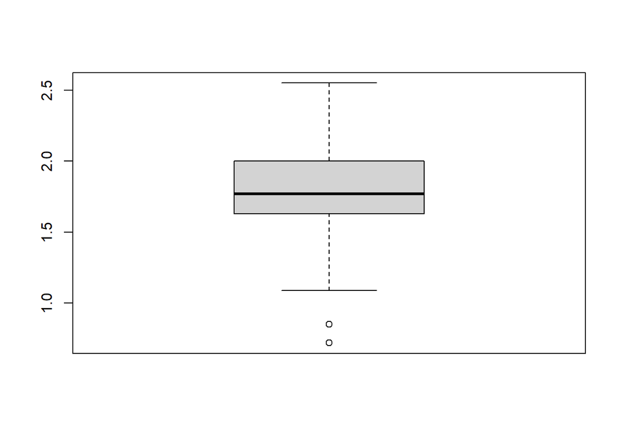

```r
boxplot(nicotina_df)
```

Veamos cual es la media de estos datos.

```r
mean(nicotina_df)
```

```
## [1] 1.77275
```

la parte superior y la parte inferior de la caja son el percentil del $75$ y $25$. La mediana es la linea horizontal que esta dentro de la caja. Las lineas discontinuas, tambien llamadas como bigotes se extienden desde la parte superior e inferior del cuadro para indicar el rango de la mayor parte de los datos. Por defecto, la función de $R$ extiende los bigotes al punto más allá de la caj, execepto que no ira mas allá de $1.5$ veces el rango intercuartil.

### Gráfica de cuantiles.

El propósito de las gráficas de cuantiles consiste en describir, en forma de muestra, la función de distribución acumulada.

**Definición** Un cuantil de una muestra, $q(f)$, es un valor para el que una fracción específica $f$ de los valores de los datos es menor que o igual a $q(f)$

Una gráfica de cuantiles simplemente *gráfica los valores de los datos en el eje vertical contra una evaluación empírica de la fracción de observaciones excedidad por los valores de los datos*

### Detección de desviaciones de la normalidad.

##Gráfica de cuantiles-cuantiles normales.

La metodología incluye una gráfica de los cuantiles empíricos recién presentados contra el cuantil correspondiente de la distribución normal

**Definición** La **gráfica de cuantiles-cuantiles normales* es una grafica de $y_{(i)}$ observaciones ordenadas contra $q_{0,1}(f_{i})$, donde $f_{i}=\frac{i-\fra{3}{8}}{n+\frac{1}{4}}$

Una relación cercana a una línea recta sugiere que los datos provienen de una distribución normal. La intersección en el eje vertical es una estimación de la media de la población $\mu$ y la pendiente es una estimación de la desviación estándar $\sigma$. **Ejemplo**

```r
#repeticiones del experimento
rep = 100
#tamano de la muestra
n = 16
#media de la población
mu = 800
#desviacion estandar de la población
sigma = 40
#matriz para guardar las muestras
muestras = matrix(data = NA, nrow = rep, ncol = n)
#Generacion de las muestras de tamaño n provenientes de una población
#Normal con media mu y desviación sigma
for (i in 1:rep) {
  muestras[i,] = rnorm(n, mean=mu, sd=sigma)
}
#Convertir la matriz muestras en un data.frame
muestras = data.frame(muestras)
head(muestras)
```

|  | X1 | X2 | X3 | X4 | X5 | X6 | X7 | X8 | X9 | X10 | X11 | X12 | X13 | X14 | X15 | X16 |
| --- | --- | --- | --- | --- | --- | --- | --- | --- | --- | --- | --- | --- | --- | --- | --- | --- |
| 1 | 875.9449 | 785.4168 | 694.2892 | 742.0930 | 863.5399 | 764.2242 | 774.8496 | 720.3498 | 788.8755 | 747.9672 | 812.1717 | 793.8754 | 875.0187 | 823.6492 | 766.9290 | 763.7831 |
| 2 | 782.0073 | 804.2104 | 745.9486 | 864.9270 | 795.2124 | 777.7110 | 780.1725 | 820.1729 | 782.7179 | 819.2681 | 799.5962 | 876.9989 | 805.8552 | 831.9437 | 795.7654 | 816.2389 |
| 3 | 839.2001 | 713.4277 | 855.8894 | 824.2727 | 766.6253 | 824.9605 | 790.9627 | 763.9969 | 798.1334 | 772.8257 | 810.0477 | 772.2421 | 843.9973 | 759.8422 | 851.8019 | 835.6525 |
| 4 | 813.2029 | 782.6197 | 759.3527 | 790.0818 | 756.0925 | 822.3907 | 755.6058 | 797.1966 | 778.6511 | 782.2635 | 804.7994 | 843.2927 | 793.6527 | 827.5895 | 736.8091 | 730.3910 |
| 5 | 807.7768 | 818.3124 | 766.1143 | 865.2936 | 791.3885 | 829.4789 | 787.2731 | 872.9761 | 861.7115 | 802.7763 | 767.7130 | 752.7440 | 787.0457 | 770.1466 | 792.6402 | 854.6601 |
| 6 | 822.1292 | 882.3585 | 803.6476 | 766.9607 | 827.7356 | 850.9520 | 761.3998 | 843.7814 | 835.8094 | 740.5094 | 844.5443 | 874.5247 | 819.7916 | 854.2890 | 864.1926 | 779.7088 |

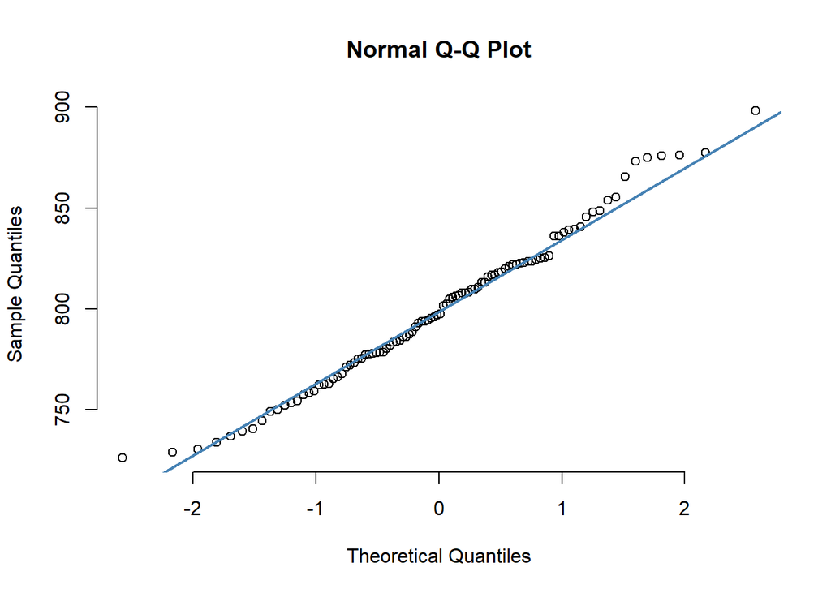

```r
qqnorm(muestras$X1, pch = 1, frame = FALSE)
qqline(muestras$X1, col = "steelblue", lwd = 2)
```

### Graficación de la probabilidad normal..

```r
Estación_1 <-c(5.30, 4.980, 13.700, 11.910, 10.730, 8.130, 11.400, 26.850, 860, 17.660, 2.200, 22.800, 4.250, 1.130, 15.040, 1.690)

Estación_2 <-c(2.800, 4.670, 6.890, 7.720, 7.030, 7.330, 2.810, 1.330, 3.320, 1.230, 2.130, 2.190, NA, NA, NA, NA)
```

```r
Número_de_organismos_m2 <-data.frame(Estación_1, Estación_2)
Número_de_organismos_m2
```

| Estación_1 | Estación_2 |
| --- | --- |
| 5.30 | 2.80 |
| 4.98 | 4.67 |
| 13.70 | 6.89 |
| 11.91 | 7.72 |
| 10.73 | 7.03 |
| 8.13 | 7.33 |
| 11.40 | 2.81 |
| 26.85 | 1.33 |
| 860.00 | 3.32 |
| 17.66 | 1.23 |

[output cut: 6 more lines]

## Distribuciones muestrales de medias

El campo de la inferencia estadística se trata básicamente con generalizaciónes y predicciones.

### Inferencias sobre la población a patir de la información de la muestra.

**Definición** La distribuciòn de probabilidad de in estadìstico se llama **distribuciòn muestral.**

## Distribuciones muestrales de medias

**Teorema del lìmite central:** si $\bar{X}$ es la media de de una muestra aleatoria de tamaño $n$ tomada de una población con media $\mu$ y varianza finita $\sigma^{2}$, entonces la forma límite de la distribución de
$$Z = \frac{\bar{X}-\mu}{\frac{\sigma}{\sqrt{n}}}$$
conforme $n \rightarrow \infty$, es la distribución normal estándar $n(z;0,1)$

**Ejemplo** Una empresa de material eléctrico fabrica bombillas de luz que tienen una duración que se distribuye aproximadamente en forma normal, con media de 800 horas y desviación estándar de 40 horas. Encuentre la probabilidad de que una muestra aleatoria de 16 bombillas tengan una vida promedio de menos de 775 horas.

```r
#repeticiones del experimento
rep = 10000
#tamano de la muestra
n = 16
#media de la población de bombillos
mu = 800
#desviacion estandar de la población de bombillos
sigma = 40
#matriz para guardar las muestras
muestras = matrix(data = NA, nrow = rep, ncol = n)
#Generacion de las muestras de tamaño n provenientes de una población
#Normal con media mu y desviación sigma
for (i in 1:rep) {
  muestras[i,] = rnorm(n, mean=mu, sd=sigma)
}
#Convertir la matriz muestras en un data.frame
muestras = data.frame(muestras)
#Crear una variable columna al final del data.frame con la proporcion de exitos
#llamada Media
head(muestras)
```

|  | X1 | X2 | X3 | X4 | X5 | X6 | X7 | X8 | X9 | X10 | X11 | X12 | X13 | X14 | X15 | X16 |
| --- | --- | --- | --- | --- | --- | --- | --- | --- | --- | --- | --- | --- | --- | --- | --- | --- |
| 1 | 789.8617 | 778.3769 | 779.1563 | 837.5954 | 795.7777 | 826.8727 | 826.9369 | 835.8096 | 793.4233 | 838.2367 | 808.6505 | 796.4618 | 766.6561 | 842.3906 | 770.3307 | 858.8765 |
| 2 | 872.5281 | 825.0033 | 709.8283 | 719.0420 | 813.7214 | 830.8374 | 822.1637 | 838.8400 | 791.3433 | 795.3835 | 844.2654 | 836.2023 | 805.8044 | 815.9455 | 901.3501 | 885.8786 |
| 3 | 786.9275 | 825.0383 | 746.9559 | 806.7009 | 726.9019 | 854.9703 | 838.0352 | 808.6181 | 859.1186 | 817.2426 | 785.0471 | 849.1303 | 748.3008 | 803.3742 | 770.9688 | 789.1209 |
| 4 | 788.1956 | 753.1554 | 805.5383 | 769.4527 | 758.3166 | 773.1721 | 793.5909 | 729.8506 | 878.3292 | 843.5744 | 900.4891 | 743.9530 | 842.1890 | 797.1219 | 824.7857 | 856.2520 |
| 5 | 803.6332 | 787.3808 | 800.0913 | 823.4482 | 798.0459 | 786.7434 | 772.5659 | 804.6281 | 780.0619 | 850.6281 | 869.9146 | 808.2808 | 785.7785 | 822.9223 | 786.4101 | 885.1213 |
| 6 | 774.9613 | 819.6533 | 825.2381 | 760.3796 | 754.5530 | 828.1543 | 826.9991 | 788.0928 | 836.0524 | 794.3911 | 803.6938 | 796.8022 | 747.1913 | 752.4596 | 764.3713 | 793.3587 |

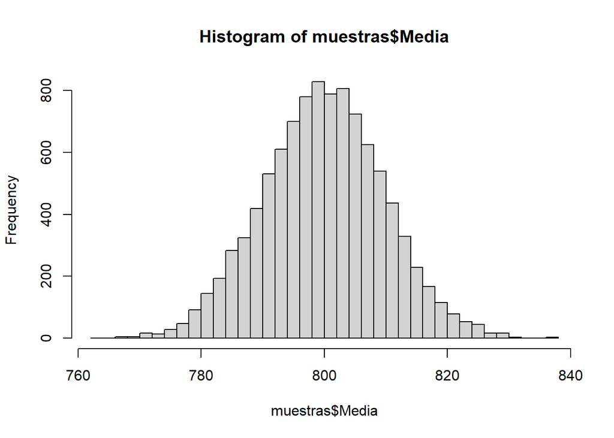

```r
muestras$Media = apply(muestras, 1, mean)
#Histograma de frecuencias para la variable aleatorio o estimador Media
hist(muestras$Media, breaks=50)
```

```r
#Media del estimador Media
mean(muestras$Media)
```

```
## [1] 799.8905
```

```r
#Varianza del estimador Media
var(muestras$Media)
```

```
## [1] 96.39959
```

```r
#Desviacion estandar del estimador Media
sd(muestras$Media)
```

```
## [1] 9.818329
```

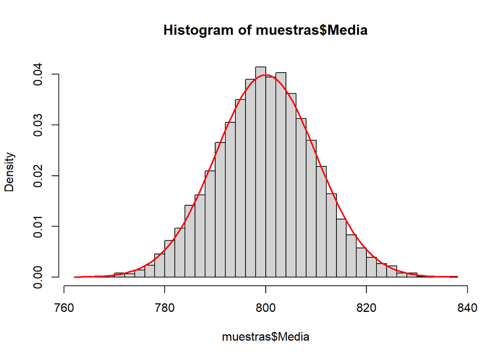

```r
#Histograma con frecuencias relativas
hist(muestras$Media, breaks=50, freq = FALSE)
#Curva normal teorica superpuesta
curve(dnorm(x, mean=mu, sd=sigma/sqrt(n)), col="red", lwd=2, add=TRUE, yaxt="n")
```

```r
# Encuentre la probabilidad de que una muestra aleatoria
# de 16 bombillas tenga una vida promedio de menos de
# 775 horas.
```

```r
#Indicadora de que Medias son menores que 775
muestras$ind = (muestras$Media < 775)
#Conteo del numero de Medias menores a 775
sum(muestras$ind)
```

```
## [1] 55
```

```r
#Proporcion del numero de Medias menores a 775
sum(muestras$ind)/rep
```

```
## [1] 0.0055
```

## Inferencias sobre la media de la población

**Ejemplo:** Un importante proceso de fabricación produce partes de componentes cilíndricos para la industria automotriz. Es importante que el proceso produzca partes que tengan una media de 5 milímetros. El ingeniero implicado hace la conjetura de que la media de la población es de 5.0 milímetros. Se lleva a cabo un experimento donde se seleccionan al azar 100 partes elaboradas por el proceso y se mide el diámetro de cada una de ellas. Se sabe que la desviación estándar de la población es $\sigma=0.1$. El experimento indica un diámetro promedio de la muestra $\bar{x}=5.027$ milímetros. ¿Esta información de la muestra parece apoyar o refutar la conjetura del ingeniero?

```r
#repeticiones del experimento
rep_2 = 10000
#tamano de la muestra
n_2 = 100
#media del diametro de las piezas
mu_2 = 5
#desviacion estandar del diametro de las piezas
sigma_2 = 0.1
#matriz para guardar las muestras
muestras_2 = matrix(data = NA, nrow = rep_2, ncol = n_2)
#Generacion de las muestras de tamaño n provenientes de una población
#Normal con media mu y desviación sigma
for (i in 1:rep) {
  muestras_2[i,] = rnorm(n_2, mean=mu_2, sd=sigma_2)
}
#Convertir la matriz muestras en un data.frame
muestras_2 = data.frame(muestras_2)
head(muestras_2)
```

|  | X1 | X2 | X3 | X4 | X5 | X6 | X7 | X8 | X9 | X10 | X11 | X12 | X13 | X14 | X15 | X16 | X17 | X18 | X19 | X20 | X21 | X22 | X23 | X24 | X25 | X26 | X27 | X28 | X29 | … |
| --- | --- | --- | --- | --- | --- | --- | --- | --- | --- | --- | --- | --- | --- | --- | --- | --- | --- | --- | --- | --- | --- | --- | --- | --- | --- | --- | --- | --- | --- | --- |
| 1 | 5.023300 | 5.099119 | 5.068979 | 5.136189 | 4.959791 | 5.214984 | 5.061424 | 5.050063 | 4.869298 | 4.966106 | 5.193641 | 4.914458 | 5.100909 | 4.994618 | 5.216220 | 4.941321 | 5.068242 | 5.020608 | 4.895619 | 5.055902 | 4.997309 | 4.895254 | 5.097696 | 5.018265 | 4.963112 | 5.192062 | 5.041777 | 5.013244 | 4.934323 | … |
| 2 | 4.815408 | 5.038842 | 4.991292 | 5.017306 | 5.114742 | 4.859198 | 5.077862 | 5.081438 | 4.834180 | 4.900527 | 5.050553 | 4.834550 | 4.967863 | 5.001400 | 5.055977 | 4.961881 | 5.155424 | 4.998026 | 5.020260 | 4.825743 | 4.921507 | 5.089786 | 4.811516 | 5.024814 | 4.934994 | 4.984833 | 5.005657 | 4.907857 | 4.955666 | … |
| 3 | 5.188782 | 4.995230 | 5.052126 | 5.085372 | 4.948285 | 4.858525 | 5.075114 | 4.938726 | 5.057774 | 4.997995 | 5.090508 | 5.230823 | 4.966882 | 5.066976 | 5.109366 | 4.948462 | 5.083972 | 4.945301 | 4.923124 | 5.016698 | 5.013840 | 5.082530 | 5.088576 | 5.097174 | 4.996416 | 4.959887 | 4.813575 | 5.145606 | 4.945161 | … |
| 4 | 5.054675 | 4.926621 | 5.087300 | 5.067356 | 4.950059 | 4.840035 | 5.009300 | 4.863128 | 4.685674 | 5.087262 | 4.951941 | 5.059998 | 5.123683 | 5.057665 | 5.153131 | 5.124387 | 4.969368 | 4.989396 | 5.205589 | 4.809278 | 4.783657 | 4.796011 | 5.132088 | 4.887182 | 4.950473 | 5.087774 | 5.008750 | 5.090102 | 5.014596 | … |
| 5 | 4.997894 | 4.839817 | 5.092108 | 4.942620 | 5.074138 | 4.925125 | 4.995675 | 5.070804 | 5.021322 | 5.160052 | 4.893767 | 5.057499 | 4.918904 | 4.988299 | 4.903900 | 4.954093 | 4.844607 | 5.049079 | 5.135360 | 4.971960 | 5.138226 | 4.975530 | 5.053183 | 4.951518 | 4.982309 | 5.023350 | 4.980035 | 5.132076 | 4.723002 | … |
| 6 | 4.820459 | 5.043642 | 4.898546 | 4.943850 | 4.895545 | 5.029656 | 5.251087 | 4.888488 | 5.016142 | 5.047302 | 5.005423 | 4.918988 | 5.024386 | 4.948811 | 5.021814 | 5.004753 | 5.021186 | 5.167987 | 4.908311 | 5.053989 | 4.989649 | 5.087257 | 5.074816 | 5.031897 | 4.884396 | 5.003398 | 4.959327 | 5.008886 | 5.160977 | … |

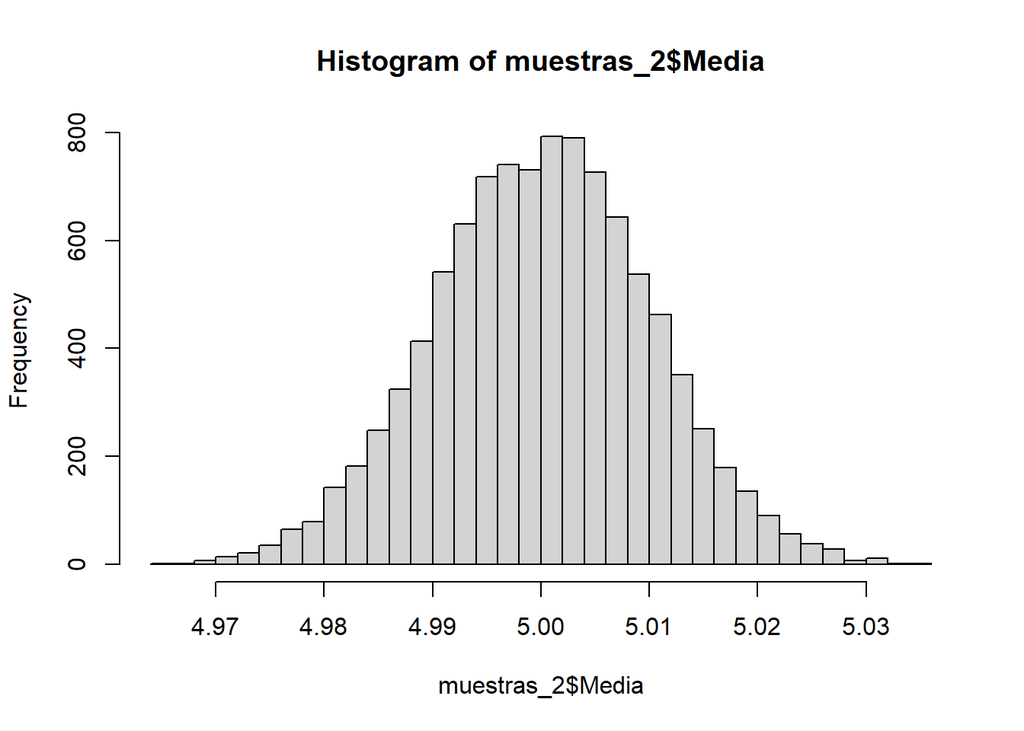

```r
#Crear una variable columna al final del data.frame con la proporcion de exitos
#llamada Media
muestras_2$Media = apply(muestras_2, 1, mean)
#Histograma de frecuencias para la variable aleatorio o estimador Media
hist(muestras_2$Media, breaks=50)
```

```r
#Media del estimador Media
mean(muestras_2$Media)
```

```
## [1] 5.000143
```

```r
#Varianza del estimador Media
var(muestras_2$Media)
```

```
## [1] 9.982659e-05
```

```r
#Desviacion estandar del estimador Media
sd(muestras_2$Media)
```

```
## [1] 0.009991326
```

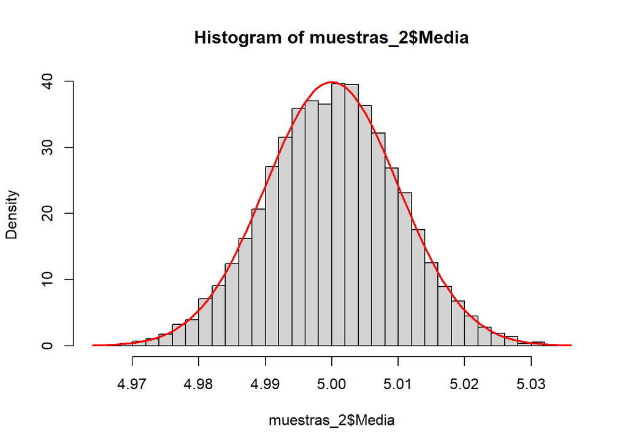

```r
#Histograma con frecuencias relativas
hist(muestras_2$Media, breaks=50, freq = FALSE)
#Curva normal teorica superpuesta
curve(dnorm(x, mean=mu_2, sd=sigma_2/sqrt(n_2)), col="red", lwd=2, add=TRUE, yaxt="n")
```

```r
# El ingeniero implicado hace la conjetura de que la media
#de la población es de 5.0 milímetros.
# Se lleva a cabo un experimento donde se seleccionan al
#azar 100 partes elaboradas por el proceso y se mide el
# diámetro de cada una de ellas.
# El experimento indica un diámetro promedio de la muestra
# x_barra = 5.027 milímetros. ¿Esta información de la
#muestra parece apoyar o refutar la conjetura del ingeniero?

#Indicadora de que Medias mayores que 5.027
muestras_2$ind = (muestras_2$Media > 5.027)
#Conteo del numero de Medias mayores a 5.027
sum(muestras_2$ind)
```

```
## [1] 38
```

```r
#Proporcion del numero de Medias mayores a 5.027
2*sum(muestras_2$ind)/rep
```

```
## [1] 0.0076
```